# Mandatory Assignment 1 - STK9900

Inger Grünbeck

2023-03-12

Importing libraries:

```r
message = FALSE
warning = FALSE

library(rcompanion)
library(car)
```

```r
library(data.table)
library(ggplot2)
theme_set(
  theme_classic() +
    theme(legend.position = "top")
  )
library(MASS)
#library(tidyverse)
```

# Exercise 1

Reading in the pollution dataset:

```r
pollution=read.table("https://www.uio.no/studier/emner/matnat/math/STK4900/data/no2.txt", header=TRUE)
```

## a)

### Method:

We inspect the mean, median, standard deviation (sd), the IQR, and the confidence interval in order to analyse variable log.no2. Further a histogram and boxplot of the variable are printed.

```r
summary(pollution$log.no2)
```

```
##    Min. 1st Qu.  Median    Mean 3rd Qu.    Max.
##   1.224   3.214   3.848   3.698   4.217   6.395
```

```r
print("SD:")
```

```
## [1] "SD:"
```

```r
sd(pollution$log.no2)
```

```
## [1] 0.7505966
```

```r
print("IQR:")
```

```
## [1] "IQR:"
```

```r
IQR(pollution$log.no2)
```

```
## [1] 1.003067
```

```r
print("The Cofidence Interval")
```

```
## [1] "The Cofidence Interval"
```

```r
print("lower limit:")
```

```
## [1] "lower limit:"
```

```r
mean(pollution$log.no2) - qt(0.975,499)*(sd(pollution$log.no2)/sqrt(500))      # lower limit
```

```
## [1] 3.632416
```

```r
print("upper limit")
```

```
## [1] "upper limit"
```

```r
mean(pollution$log.no2) + qt(0.975,499)*(sd(pollution$log.no2)/sqrt(500))     # upper limit
```

```
## [1] 3.764319
```

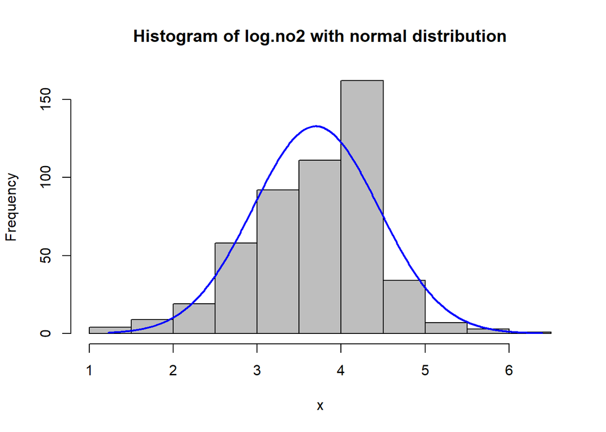

```r
plotNormalHistogram(pollution$log.no2, main="Histogram of log.no2 with normal distribution")
```

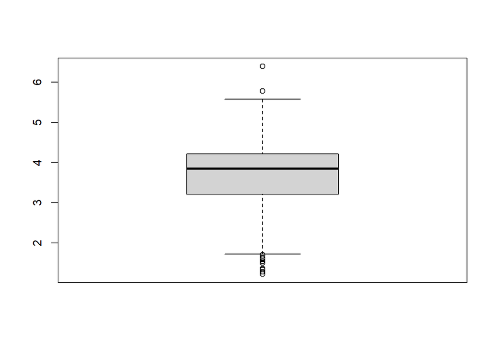

```r
boxplot(pollution$log.no2)
```

We repeat this for the variable pollution$log.cars:

```r
summary(pollution$log.cars)
```

```
##    Min. 1st Qu.  Median    Mean 3rd Qu.    Max.
##   4.127   6.176   7.425   6.973   7.793   8.349
```

```r
print("SD:")
```

```
## [1] "SD:"
```

```r
sd(pollution$log.cars)
```

```
## [1] 1.087166
```

```r
print("IQR:")
```

```
## [1] "IQR:"
```

```r
IQR(pollution$log.cars)
```

```
## [1] 1.617332
```

```r
print("The Cofidence Interval")
```

```
## [1] "The Cofidence Interval"
```

```r
print("lower limit:")
```

```
## [1] "lower limit:"
```

```r
mean(pollution$log.cars) - qt(0.975,499)*(sd(pollution$log.cars)/sqrt(500))      # lower limit
```

```
## [1] 6.877818
```

```r
print("upper limit")
```

```
## [1] "upper limit"
```

```r
mean(pollution$log.cars) + qt(0.975,499)*(sd(pollution$log.cars)/sqrt(500))     # upper limit
```

```
## [1] 7.068866
```

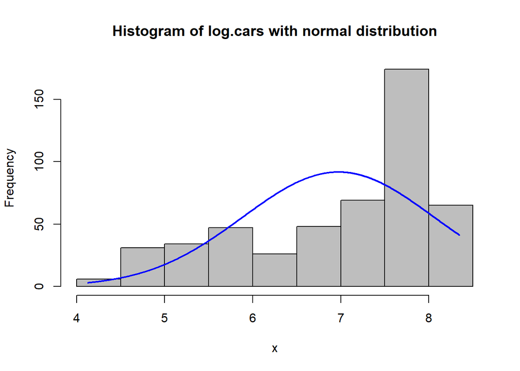

```r
plotNormalHistogram(pollution$log.cars, main="Histogram of log.cars with normal distribution")
```

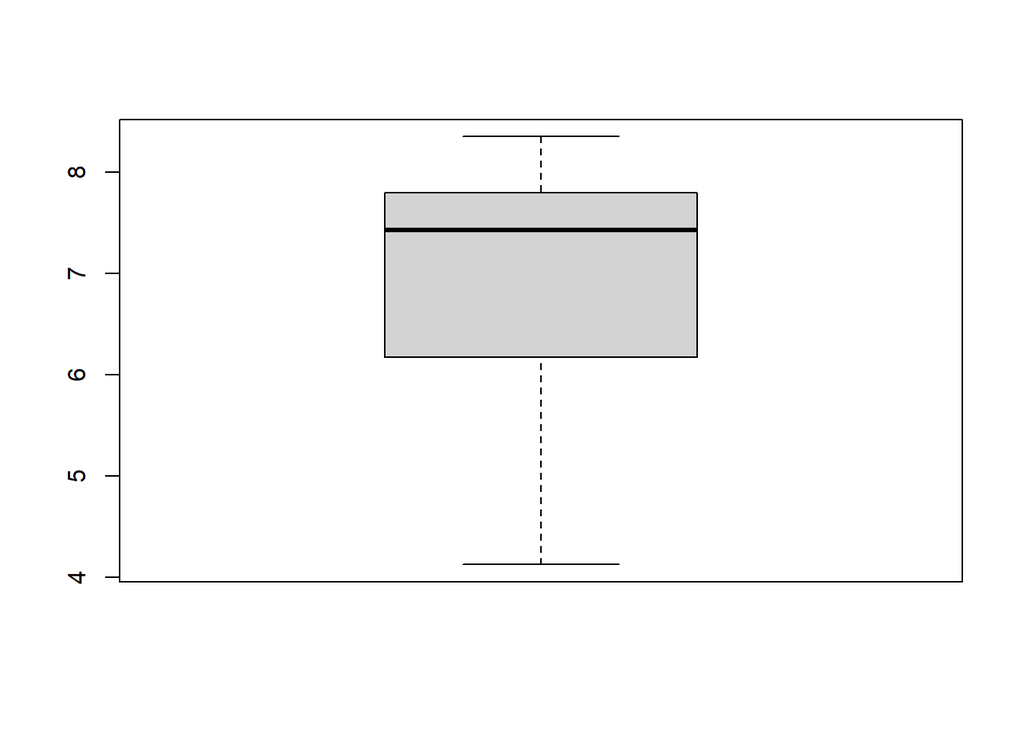

```r
boxplot(pollution$log.cars)
```

Finally, a scatterplot of the two variables is plotted in order to examine the correlation between the pollution level and the number of cars per hour. Also, the correlation of the variables is calculated:

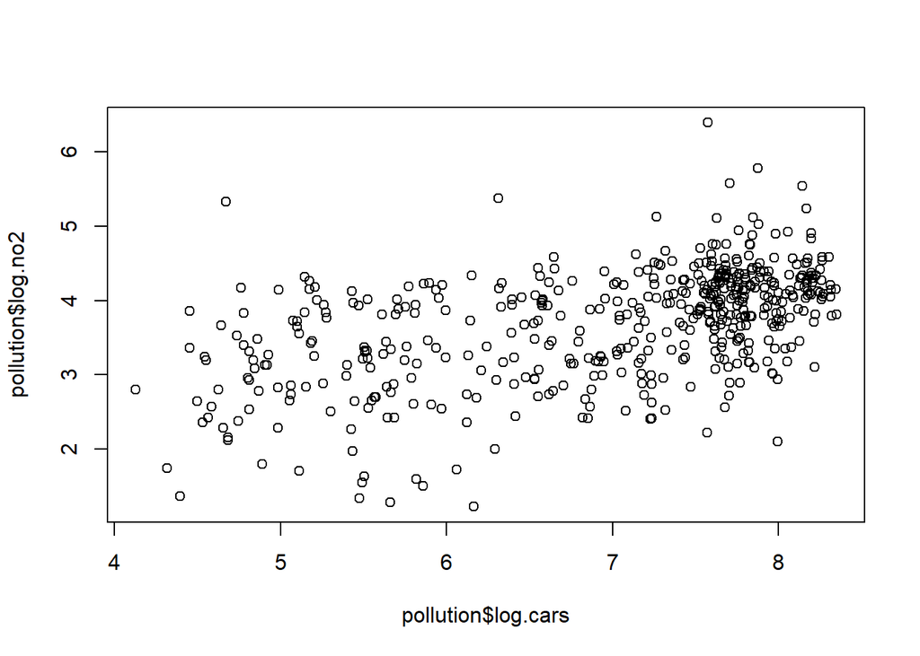

```r
plot(pollution$log.cars, pollution$log.no2)
```

```r
print("Correlation:")
```

```
## [1] "Correlation:"
```

```r
cor(pollution$log.cars, pollution$log.no2)
```

```
## [1] 0.5120504
```

### Discussion:

## b)

### Method:

A linear model is fitted, with the NO2 levels as dependent and cars/hour as dependent variable:

```r
pollution.fit = lm(log.no2~log.cars, data=pollution)
summary(pollution.fit)
```

```
##
## Call:
## lm(formula = log.no2 ~ log.cars, data = pollution)
##
## Residuals:
##      Min       1Q   Median       3Q      Max
## -2.18822 -0.40071  0.06428  0.40362  2.48472
##
## Coefficients:
##             Estimate Std. Error t value Pr(>|t|)
## (Intercept)  1.23310    0.18755   6.575 1.23e-10 ***
## log.cars     0.35353    0.02657  13.303  < 2e-16 ***
## ---
## Signif. codes:  0 '***' 0.001 '**' 0.01 '*' 0.05 '.' 0.1 ' ' 1
##
## Residual standard error: 0.6454 on 498 degrees of freedom
## Multiple R-squared:  0.2622, Adjusted R-squared:  0.2607
## F-statistic:   177 on 1 and 498 DF,  p-value: < 2.2e-16
```

The observations are plotted together with a line representing the fitted linear regression model:

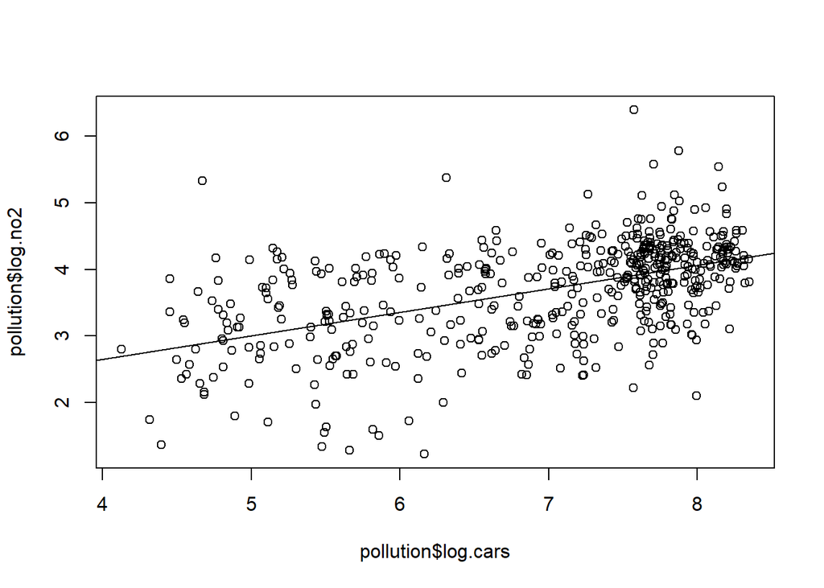

```r
plot(pollution$log.cars, pollution$log.no2)
abline(pollution.fit)
```

### Discussion)  
R^2, the coefficient of determination, tells us how much of the of the variance present in the dependent variable can be explained by the model/the independent variables. A high R^2 value indicates that a high amount of the dependent variable’s variance can be explained by the model, and therefore a good representation.

## c)

For a linear regression we assume:  
* linearity between the dependent and independent variable  
* Homoscedacity - constant variance in the residuals  
* Normally distributed residuals  
* Uncorrelated errors (This assumptions I have not testes for, as this not has been part of the curriculum yet)

### Method:

For the first assumption, we plot a CPR (component-plus-residual) plot:

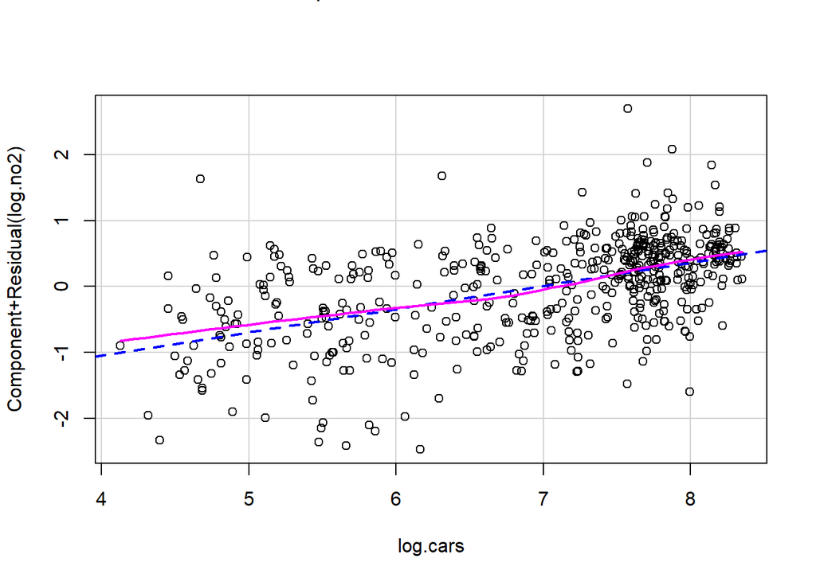

```r
crPlots(pollution.fit)
```

For the homoscedacity check, the residuals vs fitted values are plotted. If there is no systematic pattern in the residuals, the assumption is fulfilled.

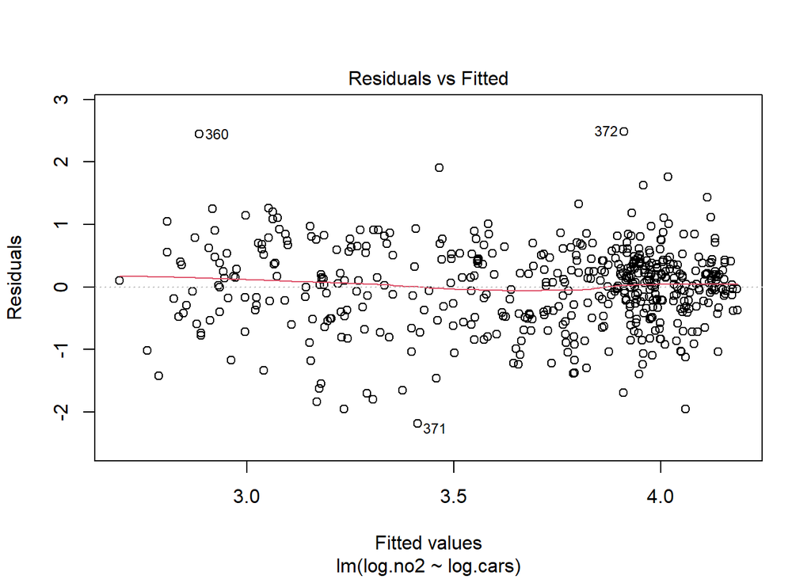

```r
plot(pollution.fit, 1)
```

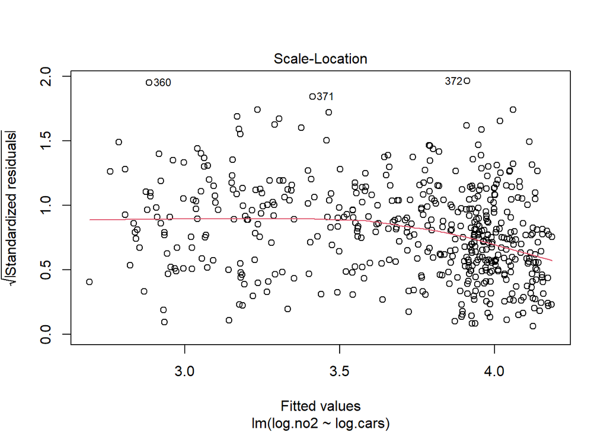

```r
plot(pollution.fit, 3)
```

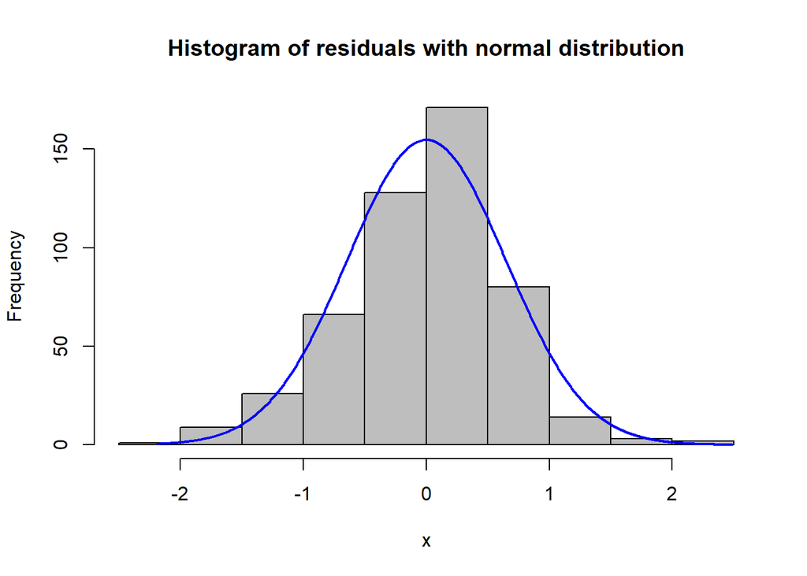

```r
plotNormalHistogram(pollution.fit$residuals, main="Histogram of residuals with normal distribution")
```

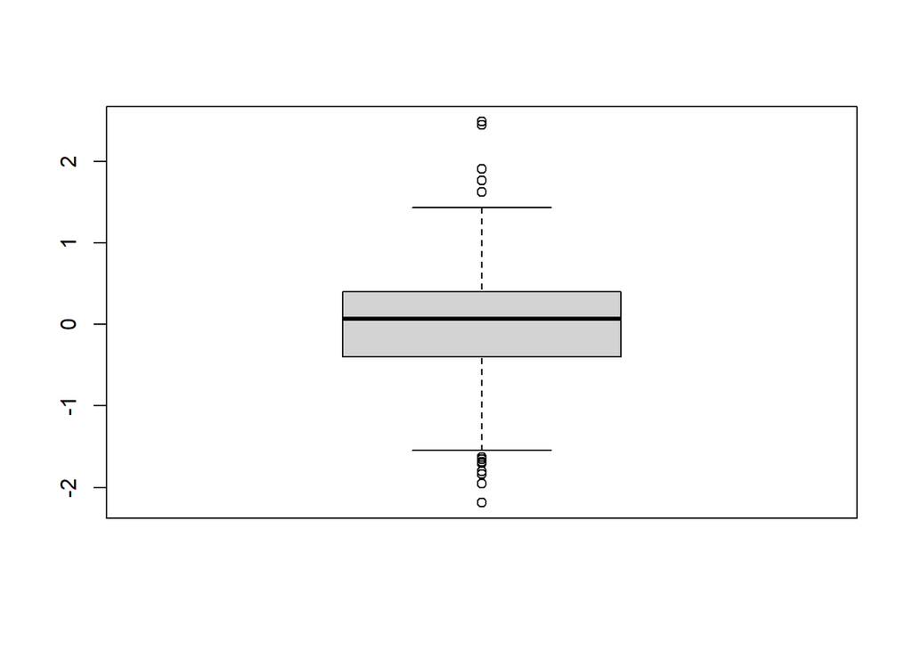

```r
boxplot(pollution.fit$residuals)
```

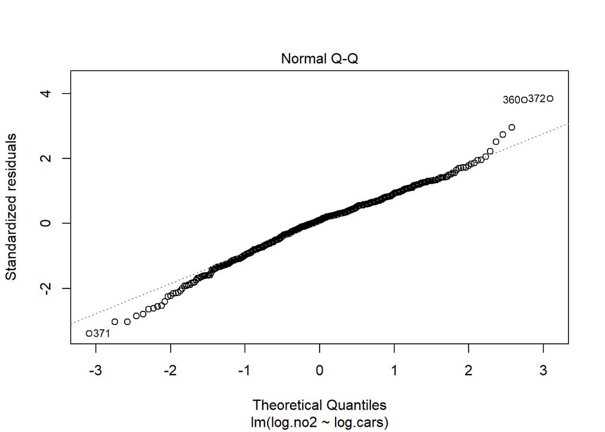

```r
plot(pollution.fit, 2)
```

### Discussion:

## d)

### Method:

Im applying the backwards-method in order to exclude predictors in possible multiple models. I start by including all variables and exclude one and one based on their significance/p-value. The models are being evaluated based on the R^2. I test both applying a log-transformation to the variables, as well as including their the second degree terms.

Model 1:

```r
pollution.fit.1=lm(log.no2~log.cars+temp+wind.speed+hour.of.day, data=pollution)
summary(pollution.fit.1)
```

```
##
## Call:
## lm(formula = log.no2 ~ log.cars + temp + wind.speed + hour.of.day,
##     data = pollution)
##
## Residuals:
##      Min       1Q   Median       3Q      Max
## -2.24876 -0.32070  0.03084  0.33860  1.96057
##
## Coefficients:
##              Estimate Std. Error t value Pr(>|t|)
## (Intercept)  1.152131   0.175045   6.582 1.19e-10 ***
## log.cars     0.456974   0.028411  16.084  < 2e-16 ***
## temp        -0.026855   0.003905  -6.877 1.85e-11 ***
## wind.speed  -0.149334   0.014076 -10.609  < 2e-16 ***
## hour.of.day -0.013025   0.004452  -2.926   0.0036 **
## ---
## Signif. codes:  0 '***' 0.001 '**' 0.01 '*' 0.05 '.' 0.1 ' ' 1
##
## Residual standard error: 0.5508 on 495 degrees of freedom
## Multiple R-squared:  0.4658, Adjusted R-squared:  0.4615
## F-statistic: 107.9 on 4 and 495 DF,  p-value: < 2.2e-16
```

Model 3:

```r
pollution.fit.3=lm(log.no2~log.cars+temp+wind.speed, data=pollution)
summary(pollution.fit.3)
```

```
##
## Call:
## lm(formula = log.no2 ~ log.cars + temp + wind.speed, data = pollution)
##
## Residuals:
##      Min       1Q   Median       3Q      Max
## -2.13980 -0.33142  0.04882  0.35257  1.97666
##
## Coefficients:
##              Estimate Std. Error t value Pr(>|t|)
## (Intercept)  1.316491   0.167043   7.881 2.07e-14 ***
## log.cars     0.409026   0.023384  17.492  < 2e-16 ***
## temp        -0.026447   0.003932  -6.725 4.83e-11 ***
## wind.speed  -0.146594   0.014152 -10.359  < 2e-16 ***
## ---
## Signif. codes:  0 '***' 0.001 '**' 0.01 '*' 0.05 '.' 0.1 ' ' 1
##
## Residual standard error: 0.555 on 496 degrees of freedom
## Multiple R-squared:  0.4566, Adjusted R-squared:  0.4533
## F-statistic: 138.9 on 3 and 496 DF,  p-value: < 2.2e-16
```

Model 4:

```r
pollution.fit.4=lm(log.no2~log.cars+wind.speed, data=pollution)
summary(pollution.fit.4)
```

```
##
## Call:
## lm(formula = log.no2 ~ log.cars + wind.speed, data = pollution)
##
## Residuals:
##      Min       1Q   Median       3Q      Max
## -2.03158 -0.34600  0.01792  0.39106  2.10633
##
## Coefficients:
##             Estimate Std. Error t value Pr(>|t|)
## (Intercept)  1.54518    0.17067   9.054   <2e-16 ***
## log.cars     0.37928    0.02396  15.828   <2e-16 ***
## wind.speed  -0.16088    0.01460 -11.019   <2e-16 ***
## ---
## Signif. codes:  0 '***' 0.001 '**' 0.01 '*' 0.05 '.' 0.1 ' ' 1
##
## Residual standard error: 0.5791 on 497 degrees of freedom
## Multiple R-squared:  0.407,  Adjusted R-squared:  0.4047
## F-statistic: 170.6 on 2 and 497 DF,  p-value: < 2.2e-16
```

In order to see if a log transformation might affect the relationship between the dependent and independent variables, the not transformed variables are also transformed. Temperature is not transformed, as it has negative values.

Model 5:

```r
pollution.fit.5=lm(log.no2~log.cars+temp+log(wind.speed)+log(hour.of.day), data=pollution)
summary(pollution.fit.5)
```

```
##
## Call:
## lm(formula = log.no2 ~ log.cars + temp + log(wind.speed) + log(hour.of.day),
##     data = pollution)
##
## Residuals:
##      Min       1Q   Median       3Q      Max
## -2.26406 -0.31784  0.04366  0.34532  1.83379
##
## Coefficients:
##                   Estimate Std. Error t value Pr(>|t|)
## (Intercept)       1.111953   0.169410   6.564 1.33e-10 ***
## log.cars          0.461040   0.031041  14.852  < 2e-16 ***
## temp             -0.026922   0.003853  -6.988 9.07e-12 ***
## log(wind.speed)  -0.415333   0.036410 -11.407  < 2e-16 ***
## log(hour.of.day) -0.098007   0.041880  -2.340   0.0197 *
## ---
## Signif. codes:  0 '***' 0.001 '**' 0.01 '*' 0.05 '.' 0.1 ' ' 1
##
## Residual standard error: 0.5431 on 495 degrees of freedom
## Multiple R-squared:  0.4807, Adjusted R-squared:  0.4766
## F-statistic: 114.6 on 4 and 495 DF,  p-value: < 2.2e-16
```

Model 6:

```r
pollution.fit.6=lm(log.no2~log.cars+temp+log(wind.speed), data=pollution)
summary(pollution.fit.6)
```

```
##
## Call:
## lm(formula = log.no2 ~ log.cars + temp + log(wind.speed), data = pollution)
##
## Residuals:
##      Min       1Q   Median       3Q      Max
## -2.07759 -0.33892  0.05458  0.36666  1.83266
##
## Coefficients:
##                  Estimate Std. Error t value Pr(>|t|)
## (Intercept)      1.229009   0.162586   7.559 1.98e-13 ***
## log.cars         0.411979   0.022995  17.916  < 2e-16 ***
## temp            -0.026304   0.003861  -6.813 2.79e-11 ***
## log(wind.speed) -0.414496   0.036572 -11.334  < 2e-16 ***
## ---
## Signif. codes:  0 '***' 0.001 '**' 0.01 '*' 0.05 '.' 0.1 ' ' 1
##
## Residual standard error: 0.5455 on 496 degrees of freedom
## Multiple R-squared:  0.475,  Adjusted R-squared:  0.4718
## F-statistic: 149.6 on 3 and 496 DF,  p-value: < 2.2e-16
```

Testing if including the second degree term of the variables will improve the model. Model 7:

```r
pollution.fit.7=lm(log.no2~log.cars+I(log.cars^2)+temp+I(temp^2)+wind.speed+I(wind.speed^2)+hour.of.day+I(hour.of.day^2), data=pollution)
summary(pollution.fit.7)
```

```
##
## Call:
## lm(formula = log.no2 ~ log.cars + I(log.cars^2) + temp + I(temp^2) +
##     wind.speed + I(wind.speed^2) + hour.of.day + I(hour.of.day^2),
##     data = pollution)
##
## Residuals:
##      Min       1Q   Median       3Q      Max
## -2.07791 -0.32530  0.02189  0.36192  1.85442
##
## Coefficients:
##                    Estimate Std. Error t value Pr(>|t|)
## (Intercept)       4.7410924  1.0699553   4.431 1.16e-05 ***
## log.cars         -0.5744937  0.3322757  -1.729  0.08444 .
## I(log.cars^2)     0.0799072  0.0253074   3.157  0.00169 **
## temp             -0.0281999  0.0039124  -7.208 2.16e-12 ***
## I(temp^2)         0.0002639  0.0003775   0.699  0.48480
## wind.speed       -0.3749046  0.0436121  -8.596  < 2e-16 ***
## I(wind.speed^2)   0.0297334  0.0054763   5.430 8.90e-08 ***
## hour.of.day      -0.0329595  0.0244929  -1.346  0.17903
## I(hour.of.day^2)  0.0008904  0.0008744   1.018  0.30899
## ---
## Signif. codes:  0 '***' 0.001 '**' 0.01 '*' 0.05 '.' 0.1 ' ' 1
##
## Residual standard error: 0.5331 on 491 degrees of freedom
## Multiple R-squared:  0.5036, Adjusted R-squared:  0.4955
## F-statistic: 62.26 on 8 and 491 DF,  p-value: < 2.2e-16
```

Model 8:

```r
pollution.fit.8=lm(log.no2~log.cars+I(log.cars^2)+temp+I(temp^2)+wind.speed+I(wind.speed^2)+hour.of.day, data=pollution)
summary(pollution.fit.8)
```

```
##
## Call:
## lm(formula = log.no2 ~ log.cars + I(log.cars^2) + temp + I(temp^2) +
##     wind.speed + I(wind.speed^2) + hour.of.day, data = pollution)
##
## Residuals:
##      Min       1Q   Median       3Q      Max
## -2.00476 -0.33674  0.02924  0.35946  1.82597
##
## Coefficients:
##                   Estimate Std. Error t value Pr(>|t|)
## (Intercept)      4.6066558  1.0618207   4.338 1.74e-05 ***
## log.cars        -0.5365889  0.3301970  -1.625  0.10479
## I(log.cars^2)    0.0748395  0.0248142   3.016  0.00269 **
## temp            -0.0278030  0.0038931  -7.142 3.34e-12 ***
## I(temp^2)        0.0002075  0.0003734   0.556  0.57869
## wind.speed      -0.3734395  0.0435900  -8.567  < 2e-16 ***
## I(wind.speed^2)  0.0292781  0.0054582   5.364 1.25e-07 ***
## hour.of.day     -0.0084495  0.0045468  -1.858  0.06372 .
## ---
## Signif. codes:  0 '***' 0.001 '**' 0.01 '*' 0.05 '.' 0.1 ' ' 1
##
## Residual standard error: 0.5332 on 492 degrees of freedom
## Multiple R-squared:  0.5025, Adjusted R-squared:  0.4954
## F-statistic:    71 on 7 and 492 DF,  p-value: < 2.2e-16
```

Model9:

```r
pollution.fit.9=lm(log.no2~log.cars+I(log.cars^2)+temp+wind.speed+I(wind.speed^2)+hour.of.day, data=pollution)
summary(pollution.fit.9)
```

```
##
## Call:
## lm(formula = log.no2 ~ log.cars + I(log.cars^2) + temp + wind.speed +
##     I(wind.speed^2) + hour.of.day, data = pollution)
##
## Residuals:
##      Min       1Q   Median       3Q      Max
## -2.00854 -0.33453  0.02454  0.35820  1.82492
##
## Coefficients:
##                  Estimate Std. Error t value Pr(>|t|)
## (Intercept)      4.620939   1.060765   4.356 1.61e-05 ***
## log.cars        -0.539959   0.329910  -1.637  0.10233
## I(log.cars^2)    0.075157   0.024790   3.032  0.00256 **
## temp            -0.027290   0.003779  -7.221 1.97e-12 ***
## wind.speed      -0.371854   0.043466  -8.555  < 2e-16 ***
## I(wind.speed^2)  0.029067   0.005441   5.342 1.41e-07 ***
## hour.of.day     -0.008471   0.004543  -1.864  0.06286 .
## ---
## Signif. codes:  0 '***' 0.001 '**' 0.01 '*' 0.05 '.' 0.1 ' ' 1
##
## Residual standard error: 0.5328 on 493 degrees of freedom
## Multiple R-squared:  0.5022, Adjusted R-squared:  0.4961
## F-statistic: 82.89 on 6 and 493 DF,  p-value: < 2.2e-16
```

Model 10:

```r
pollution.fit.10=lm(log.no2~I(log.cars^2)+temp+wind.speed+I(wind.speed^2)+hour.of.day, data=pollution)
summary(pollution.fit.10)
```

```
##
## Call:
## lm(formula = log.no2 ~ I(log.cars^2) + temp + wind.speed + I(wind.speed^2) +
##     hour.of.day, data = pollution)
##
## Residuals:
##      Min       1Q   Median       3Q      Max
## -2.08213 -0.32288  0.02327  0.34721  1.81603
##
## Coefficients:
##                  Estimate Std. Error t value Pr(>|t|)
## (Intercept)      2.894267   0.110817  26.117  < 2e-16 ***
## I(log.cars^2)    0.034724   0.002069  16.786  < 2e-16 ***
## temp            -0.027190   0.003785  -7.183 2.52e-12 ***
## wind.speed      -0.367001   0.043438  -8.449 3.32e-16 ***
## I(wind.speed^2)  0.028565   0.005442   5.249 2.27e-07 ***
## hour.of.day     -0.011171   0.004240  -2.634  0.00869 **
## ---
## Signif. codes:  0 '***' 0.001 '**' 0.01 '*' 0.05 '.' 0.1 ' ' 1
##
## Residual standard error: 0.5337 on 494 degrees of freedom
## Multiple R-squared:  0.4995, Adjusted R-squared:  0.4944
## F-statistic:  98.6 on 5 and 494 DF,  p-value: < 2.2e-16
```

MOdel 11:

```r
pollution.fit.11=lm(log.no2~I(log.cars^2)+temp+wind.speed+I(wind.speed^2), data=pollution)
summary(pollution.fit.11)
```

```
##
## Call:
## lm(formula = log.no2 ~ I(log.cars^2) + temp + wind.speed + I(wind.speed^2),
##     data = pollution)
##
## Residuals:
##      Min       1Q   Median       3Q      Max
## -1.99114 -0.33111  0.04251  0.36930  1.82765
##
## Coefficients:
##                  Estimate Std. Error t value Pr(>|t|)
## (Intercept)      2.900016   0.111459  26.019  < 2e-16 ***
## I(log.cars^2)    0.031692   0.001729  18.327  < 2e-16 ***
## temp            -0.026870   0.003806  -7.060 5.66e-12 ***
## wind.speed      -0.365108   0.043692  -8.356 6.57e-16 ***
## I(wind.speed^2)  0.028634   0.005474   5.231 2.50e-07 ***
## ---
## Signif. codes:  0 '***' 0.001 '**' 0.01 '*' 0.05 '.' 0.1 ' ' 1
##
## Residual standard error: 0.5369 on 495 degrees of freedom
## Multiple R-squared:  0.4925, Adjusted R-squared:  0.4884
## F-statistic: 120.1 on 4 and 495 DF,  p-value: < 2.2e-16
```

### Discussion:

Based on the models, log-transforming the variables will slightly improve the R^2 of the best non-transformed model (model 1: 0.4658, model 5: 0.4807). Both models included all variables, but we can see that the model’s R^2 does not decrease a lot when removing hour of day. Model 7 includes the second degree term of all variables, and results in a R^2=0.5036. But in model 11 we can see that we can remove some of the variables in model 7 and still achieve a relative high R^2 value, 0.4925. I choose to continue with model 11, as this model is also less complex/includes less variables than example model 7.

## e)

### Method:

In order to check the assumptions for model 11, I use the same methods as in Excersice 1c)-plotting CPR plots for the independent variables to check for linearity, plotting the residuals vs fitted values to check for constant variance and plotting the histogram, boxplot and qq-plot of the residuals to examine whether they are normally distributed:

The CPR plots. I have also included model 1’s CPR plots to compare the effect of including the second degree terms:

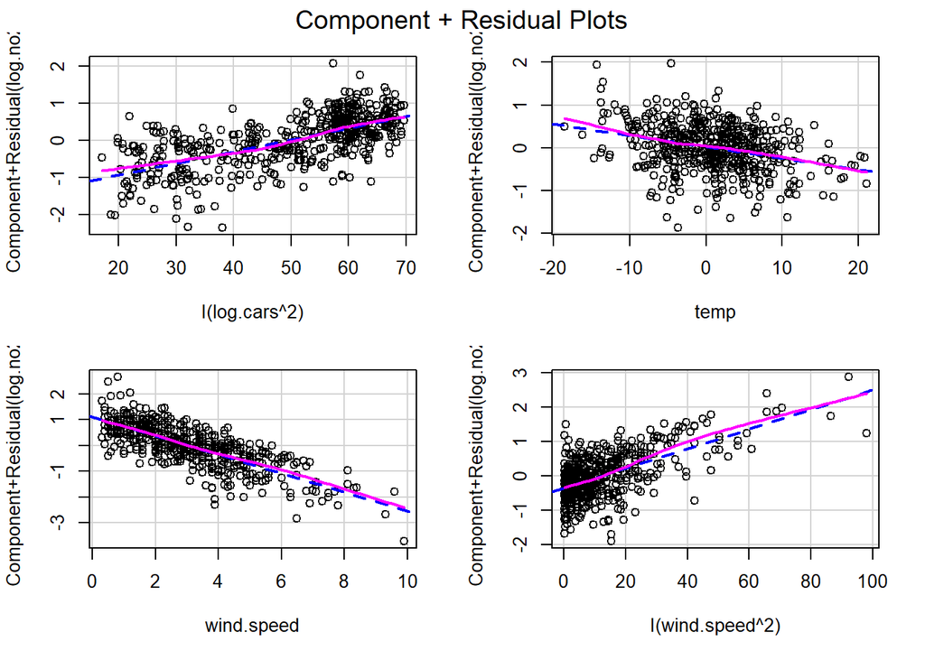

```r
crPlots(pollution.fit.11)
```

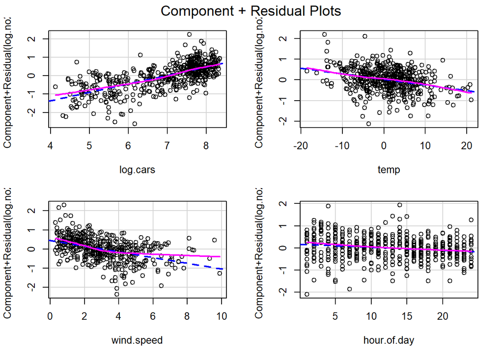

```r
crPlots(pollution.fit.1)
```

The residual vs. fitted plots:

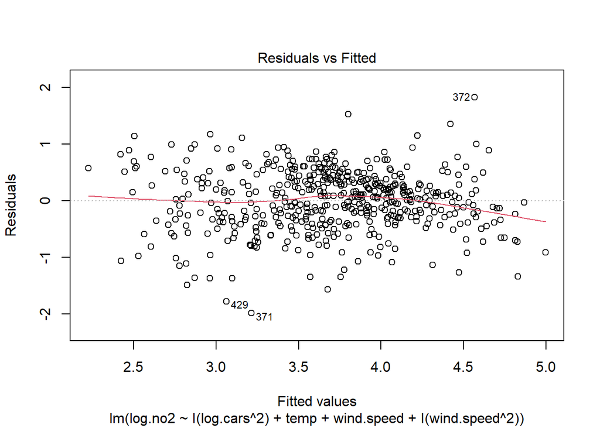

```r
plot(pollution.fit.11, 1)
```

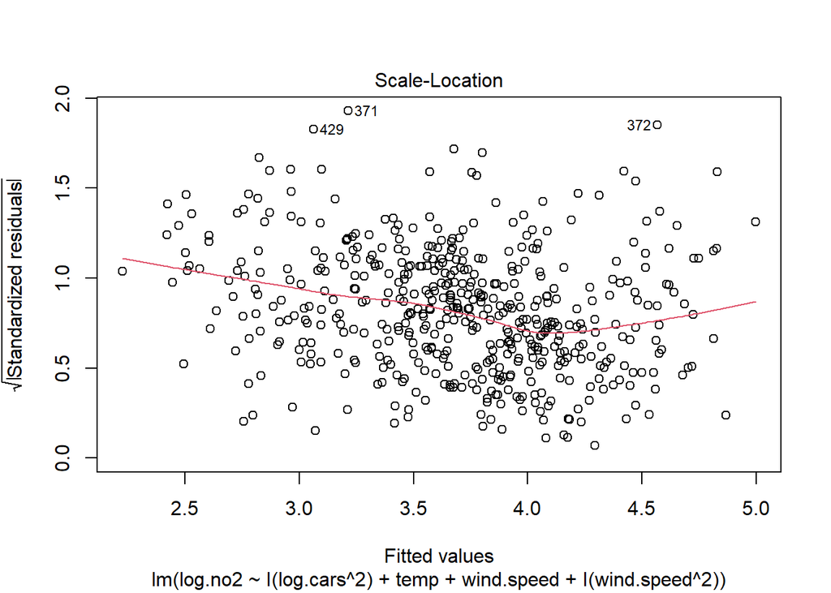

```r
plot(pollution.fit.11, 3)
```

The histogram, boxplot and qq-plot of the residuals:

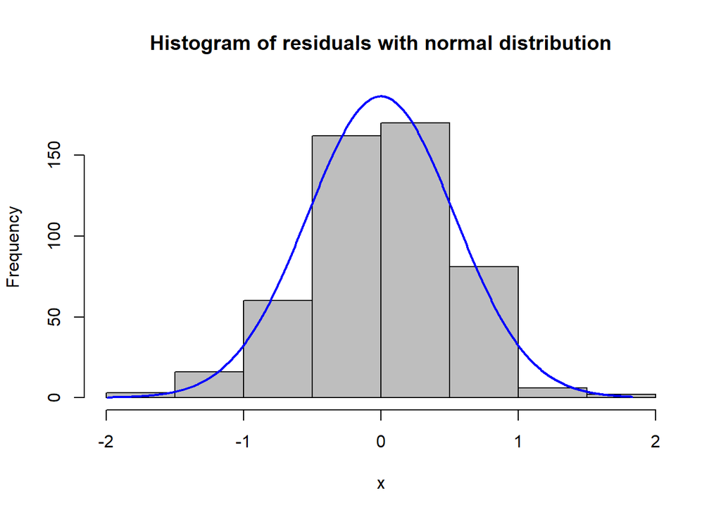

```r
plotNormalHistogram(pollution.fit.11$residuals, main="Histogram of residuals with normal distribution")
```

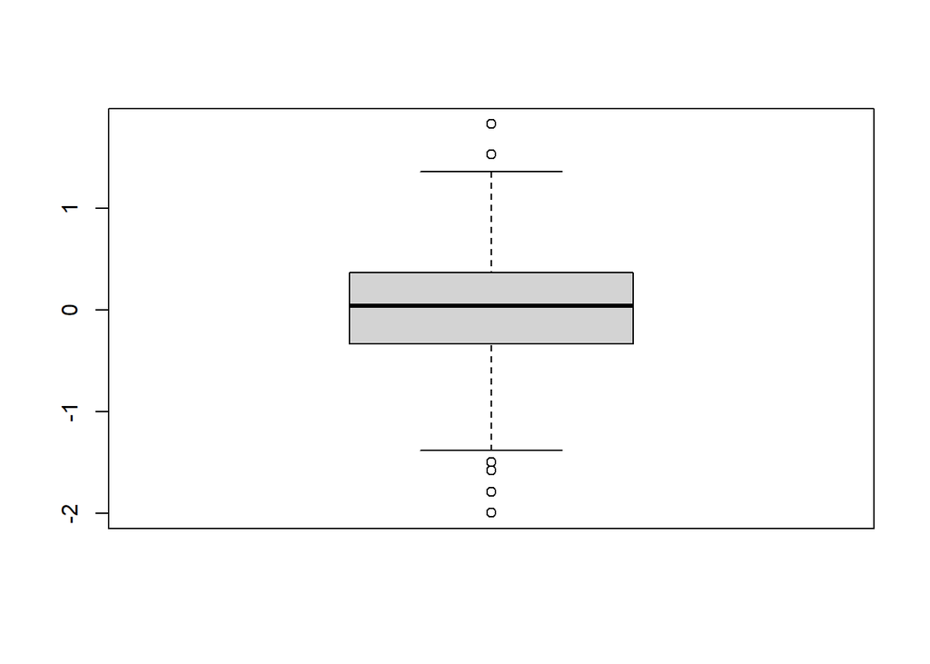

```r
boxplot(pollution.fit.11$residuals)
```

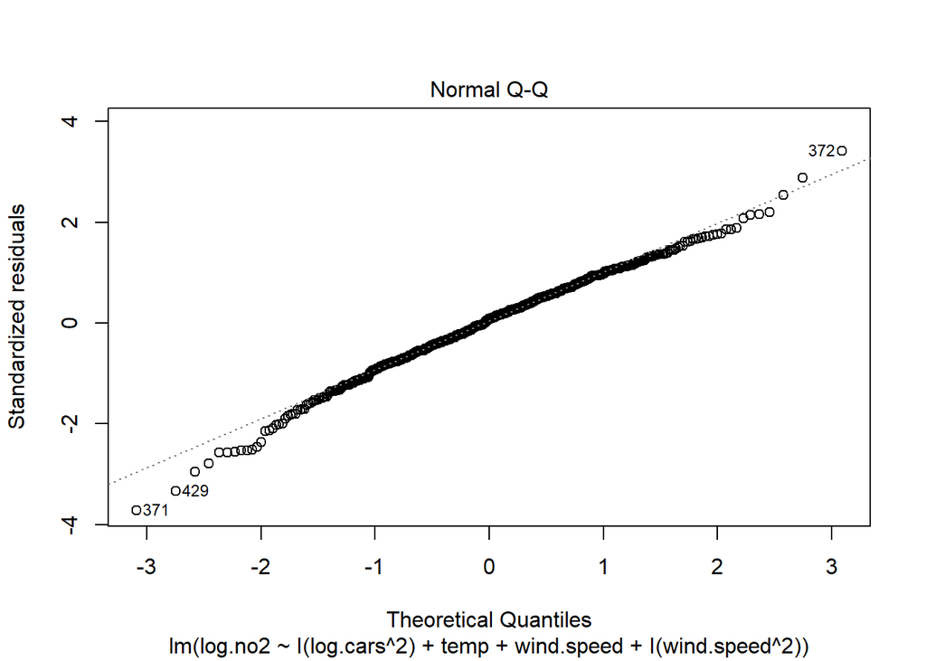

```r
plot(pollution.fit.11, 2)
```

### Discussion:

Interpreting the model:

Comment on the assumption checks:

# Excersice 2:

Reading the blood-dataset, and defining the age-variable as categorical:

```r
blood=read.table("https://www.uio.no/studier/emner/matnat/math/STK4900/data/blood.txt", header=TRUE, colClasses = c("numeric", "factor"))
```

## a)

### Method:

I first inspect the mean, sd, median, IQR, min, max, 1.Qr and 3. Qr per age group. Also a histogram and boxplot of the groups bloodpressure are printed.

```r
setDT(blood)
blood[, as.list(summary(Bloodpr)), by = age]
```

| age | Min. | 1st Qu. | Median | Mean | 3rd Qu. | Max. |
| --- | --- | --- | --- | --- | --- | --- |
| 1 | 104 | 112.0 | 117 | 122.1667 | 129.00 | 160 |
| 2 | 108 | 121.5 | 137 | 139.0833 | 157.75 | 174 |
| 3 | 110 | 138.0 | 148 | 155.1667 | 164.00 | 214 |

```r
blood[ ,list(sd=sd(Bloodpr)), by=age]
```

| age | sd |
| --- | --- |
| 1 | 15.33761 |
| 2 | 22.62524 |
| 3 | 27.71883 |

```r
blood[ ,list(IQR=IQR(Bloodpr)), by=age]
```

| age | IQR |
| --- | --- |
| 1 | 17.00 |
| 2 | 36.25 |
| 3 | 26.00 |

Plots by groups:

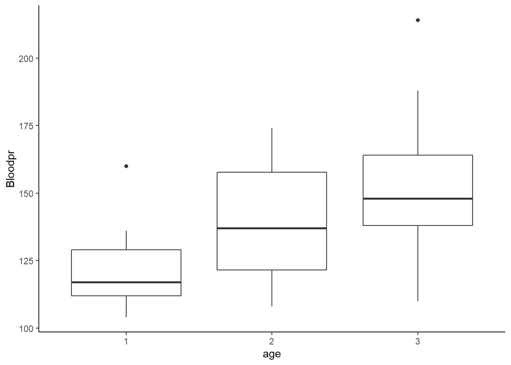

```r
ggplot(blood, aes(x=age, y=Bloodpr)) +
    geom_boxplot()
```

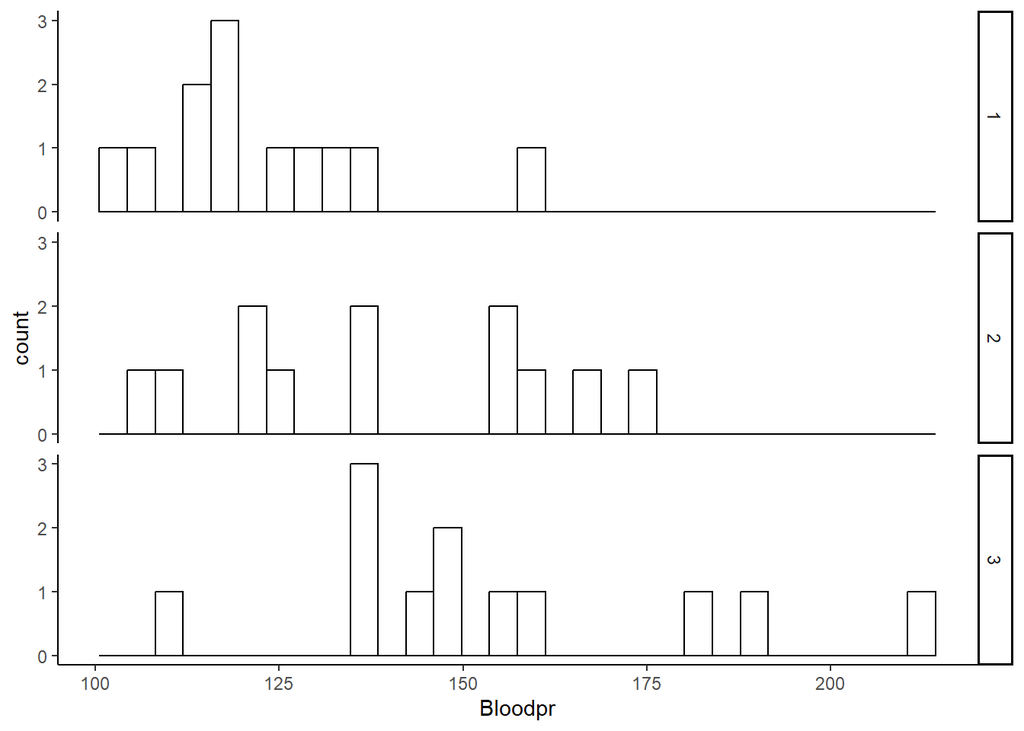

```r
ggplot(blood, aes(x = Bloodpr)) +
  geom_histogram(fill = "white", colour = "black") +
  facet_grid(age ~ .)
```

### Discussion:

## b)

### Method:

```r
aov.blood = aov(Bloodpr~age, data=blood)
summary(aov.blood)
```

```
##             Df Sum Sq Mean Sq F value  Pr(>F)
## age          2   6535    3268   6.469 0.00426 **
## Residuals   33  16670     505
## ---
## Signif. codes:  0 '***' 0.001 '**' 0.01 '*' 0.05 '.' 0.1 ' ' 1
```

## c)

### Method:

In order to compare the expected blood pressure for the groups a regression model is fit, using the blood pressure as dependent variable and age as independent variable. A treatment-contrast is used with age group 1 as reference, meaning the intercept returns the expected outcome in the reference group, while for group 2 and 3 the expected outcome relative to group 1 is returned (expected blood pressure in group 2 - expected blood pressure in group 1,and expected blood pressure in group 3 - expected blood pressure in group 1).

```r
blood.fit = lm(Bloodpr~age, data = blood)
summary(blood.fit)
```

```
##
## Call:
## lm(formula = Bloodpr ~ age, data = blood)
##
## Residuals:
##     Min      1Q  Median      3Q     Max
## -45.167 -15.583  -5.167  14.104  58.833
##
## Coefficients:
##             Estimate Std. Error t value Pr(>|t|)
## (Intercept)  122.167      6.488  18.829  < 2e-16 ***
## age2          16.917      9.176   1.844  0.07423 .
## age3          33.000      9.176   3.596  0.00104 **
## ---
## Signif. codes:  0 '***' 0.001 '**' 0.01 '*' 0.05 '.' 0.1 ' ' 1
##
## Residual standard error: 22.48 on 33 degrees of freedom
## Multiple R-squared:  0.2816, Adjusted R-squared:  0.2381
## F-statistic: 6.469 on 2 and 33 DF,  p-value: 0.004263
```

### Discussion: